# Qualità dei diamanti

Rocco Gregori

```r
library(dplyr)
library(ggplot2)
library(modelr)
```

## 1. Il paradosso

Confrontiamo la distribuzione del prezzo per ogni livello di qualità con dei boxplot:

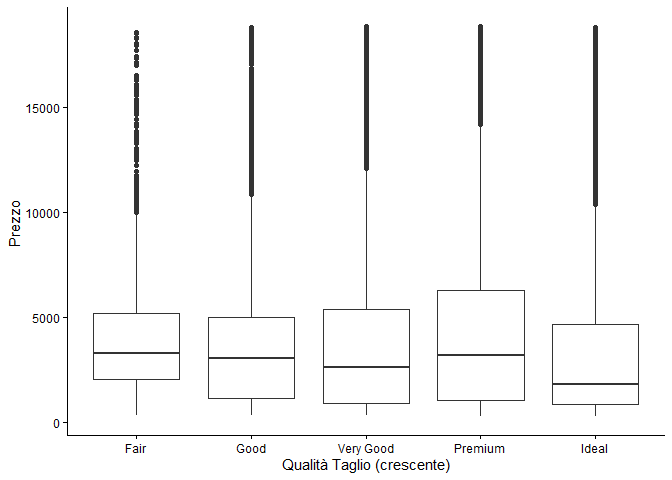

```r
ggplot(data = diamonds) +
  geom_boxplot(mapping = aes(x = cut, y = price)) +
  labs(x = "Qualità Taglio (crescente)", y = "Prezzo ") +
  theme_classic()
```

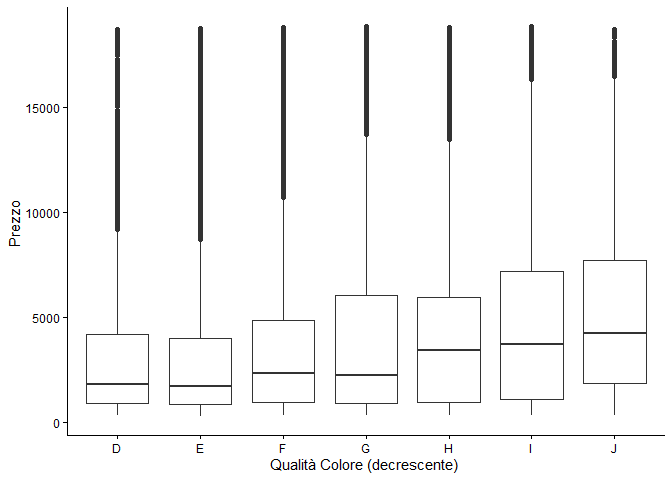

```r
ggplot(data = diamonds) +
  geom_boxplot(mapping = aes(x = color, y = price)) +
  labs(x = "Qualità Colore (decrescente) ", y = "Prezzo ") +
  theme_classic()
```

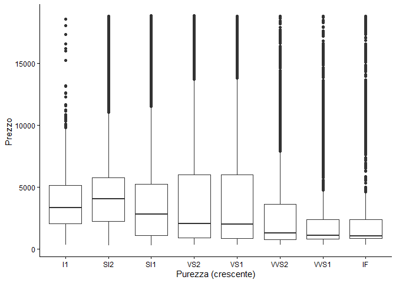

```r
ggplot(data = diamonds) +
  geom_boxplot(mapping = aes(x = clarity, y = price)) +
  labs(x = "Purezza (crescente)", y = "Prezzo ") +
  theme_classic()
```

Anche le mediane lo confermano:

```r
diamonds |>
  group_by(cut) |>
  summarise(n = n(), prezzo_mediano = median(price))
```

```
## # A tibble: 5 × 3
##   cut           n prezzo_mediano
##   <ord>     <int>          <dbl>
## 1 Fair       1610          3282
## 2 Good       4906          3050.
## 3 Very Good 12082          2648
## 4 Premium   13791          3185
## 5 Ideal     21551          1810
```

```r
diamonds |>
  group_by(color) |>
  summarise(n = n(), prezzo_mediano = median(price))
```

```
## # A tibble: 7 × 3
##   color     n prezzo_mediano
##   <ord> <int>          <dbl>
## 1 D      6775          1838
## 2 E      9797          1739
## 3 F      9542          2344.
## 4 G     11292          2242
## 5 H      8304          3460
## 6 I      5422          3730
## 7 J      2808          4234
```

```r
diamonds |>
  group_by(clarity) |>
  summarise(n = n(), prezzo_mediano = median(price))
```

```
## # A tibble: 8 × 3
##   clarity     n prezzo_mediano
##   <ord>   <int>          <dbl>
## 1 I1        741           3344
## 2 SI2      9194           4072
## 3 SI1     13065           2822
## 4 VS2     12258           2054
## 5 VS1      8171           2005
## 6 VVS2     5066           1311
## 7 VVS1     3655           1093
## 8 IF       1790           1080
```

I diamanti di qualità peggiore hanno prezzi mediani più alti di quelli migliori. Il peso (carati) del diamante è il fattore che più di tutti determina il prezzo:

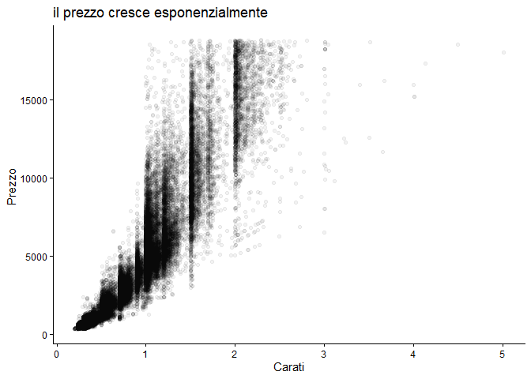

```r
ggplot(data = diamonds) +
  geom_point(mapping = aes(x = carat, y = price), alpha = 0.05) +
  labs(title="il prezzo cresce esponenzialmente", x = "Carati", y = "Prezzo ") +
  theme_classic()
```

E i diamanti di bassa qualità tendono a essere più grandi:

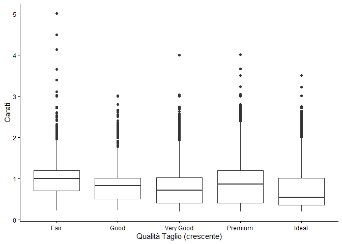

```r
ggplot(data = diamonds) +
  geom_boxplot(mapping = aes(x = cut, y = carat)) +
  labs(x = "Qualità Taglio (crescente)", y = "Carati") +
  theme_classic()
```

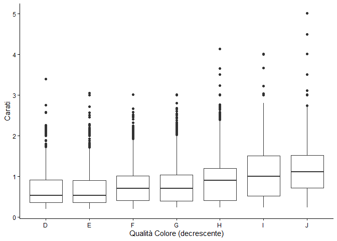

```r
ggplot(data = diamonds) +
  geom_boxplot(mapping = aes(x = color, y = carat)) +
  labs(x = "Qualità Colore (decrescente)", y = "Carati") +
  theme_classic()
```

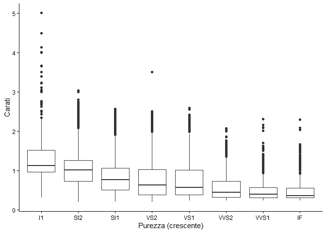

```r
ggplot(data = diamonds) +
  geom_boxplot(mapping = aes(x = clarity, y = carat)) +
  labs(x = "Purezza (crescente)", y = "Carati") +
  theme_classic()
```

```r
diamonds |>
  group_by(clarity) |>
  summarise(carati_mediani = median(carat), prezzo_mediano = median(price))
```

```
## # A tibble: 8 × 3
##   clarity carati_mediani prezzo_mediano
##   <ord>            <dbl>          <dbl>
## 1 I1                1.12           3344
## 2 SI2               1.01           4072
## 3 SI1               0.76           2822
## 4 VS2               0.63           2054
## 5 VS1               0.57           2005
## 6 VVS2              0.44           1311
## 7 VVS1              0.39           1093
## 8 IF                0.35           1080
```

i diamanti di bassa qualità costano di più non perché sono di bassa qualità, ma perché in media sono più pesanti.

## 2. Modello

Usiamo tutti i diamanti del dataset e passiamo al logaritmo in base 2 di prezzo e carati, perché in scala logaritmica la relazione diventa lineare.

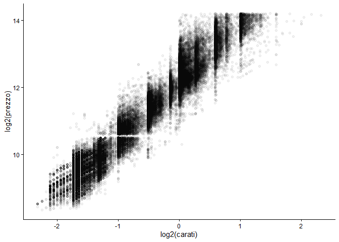

```r
diamonds2 = diamonds |>
  mutate(lprice = log2(price), lcarat = log2(carat))

ggplot(data = diamonds2) +
  geom_point(mapping = aes(x = lcarat, y = lprice), alpha = 0.05) +
  labs(x = "log2(carati)", y = "log2(prezzo)") +
  theme_classic()
```

```r
mod_carat = lm(lprice ~ lcarat, data = diamonds2)

mod_carat$coefficients
```

```
## (Intercept)      lcarat
##   12.188841    1.675817
```

```r
summary(mod_carat)$r.squared
```

```
## [1] 0.9329893
```

Il peso da solo spiega circa il 93% della variabilità del (log) prezzo.

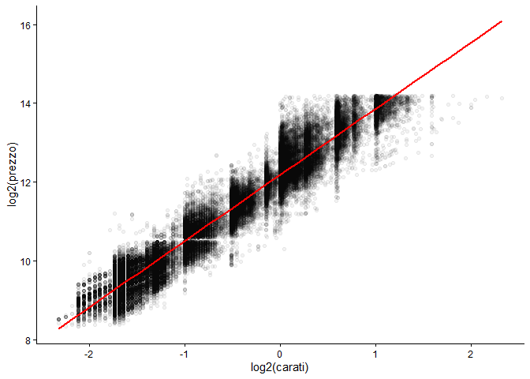

```r
ggplot(data = diamonds2, mapping = aes(x = lcarat, y = lprice)) +
  geom_point(alpha = 0.05) +
  geom_smooth(method = "lm", se = FALSE, colour = "red") +
  labs(x = "log2(carati)", y = "log2(prezzo)") +
  theme_classic()
```

I residui dicono quanto un diamante costa in più o in meno rispetto a quanto ci si aspetterebbe dal suo peso. Poiché sono in scala log2, un residuo di +1 significa che il diamante costa il doppio del previsto, -1 la metà.

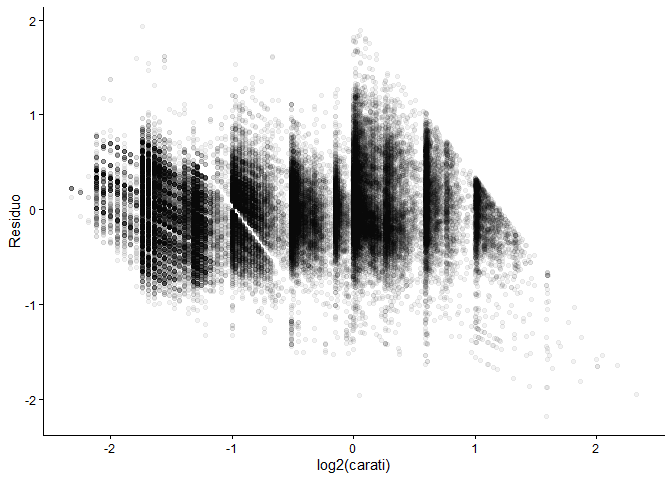

```r
diamonds2 = diamonds2 |>
  add_residuals(mod_carat, "lresid")

ggplot(data = diamonds2) +
  geom_point(mapping = aes(x = lcarat, y = lresid), alpha = 0.05) +
  labs(x = "log2(carati)", y = "Residuo") +
  theme_classic()
```

Il pattern forte del peso è stato rimosso. Ora rifacciamo i grafici iniziali usando i residui al posto del prezzo:

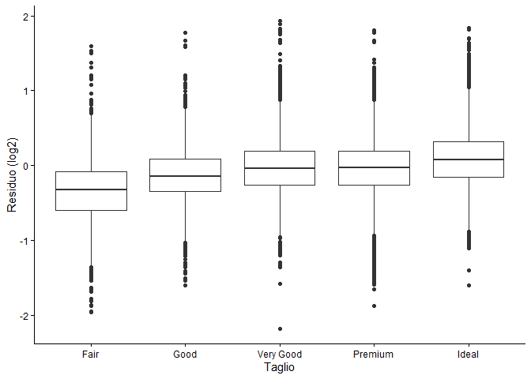

```r
ggplot(data = diamonds2) +
  geom_boxplot(mapping = aes(x = cut, y = lresid)) +
  labs(x = "Taglio", y = "Residuo (log2)") +
  theme_classic()
```

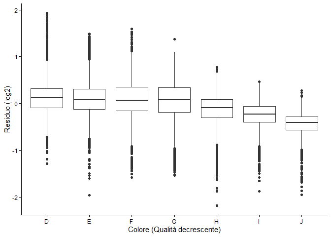

```r
ggplot(data = diamonds2) +
  geom_boxplot(mapping = aes(x = color, y = lresid)) +
  labs(x = "Colore (Qualità decrescente)", y = "Residuo (log2)") +
  theme_classic()
```

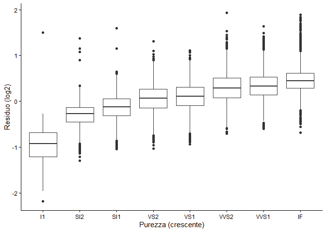

```r
ggplot(data = diamonds2) +
  geom_boxplot(mapping = aes(x = clarity, y = lresid)) +
  labs(x = "Purezza (crescente)", y = "Residuo (log2)") +
  theme_classic()
```

```r
diamonds2 |>
  group_by(clarity) |>
  summarise(residuo_mediano = median(lresid))
```

```
## # A tibble: 8 × 2
##   clarity residuo_mediano
##   <ord>             <dbl>
## 1 I1              -0.924
## 2 SI2             -0.275
## 3 SI1             -0.122
## 4 VS2              0.0621
## 5 VS1              0.108
## 6 VVS2             0.290
## 7 VVS1             0.325
## 8 IF               0.442
```

A parità di peso, il prezzo cresce con la qualità.